# l3_shoeleather_experiments

Research Seminar

Week 3: From shoe-leather to experimental approaches

Sergi Martínez

smsoler@clio.uc3m.es | Office hours: Tuesdays 10:00–13:00 (by email)

## Where are we

- We’ve learnt how to ask
- We’ve learnt how to motivate our readers to continue reading
- We will learn how to write good literature reviews and theory sections next Monday

**Shoe-leather**

## Armchair

[figure not shown]

**Armchair research**: inquiry method that relies on existing literature, logic, and speculation without gathering new empirical data

- Meaning: Studying a topic from an “armchair” by reading or thinking instead of doing fieldwork

## Old times: Armchair critic

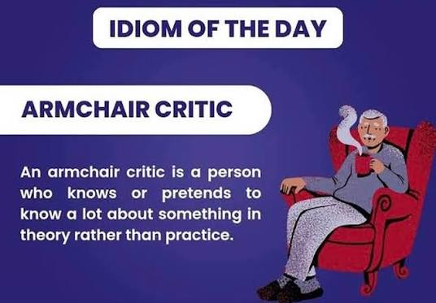

[figure not shown]

[figure not shown]

## Nowadays: armchAIr research

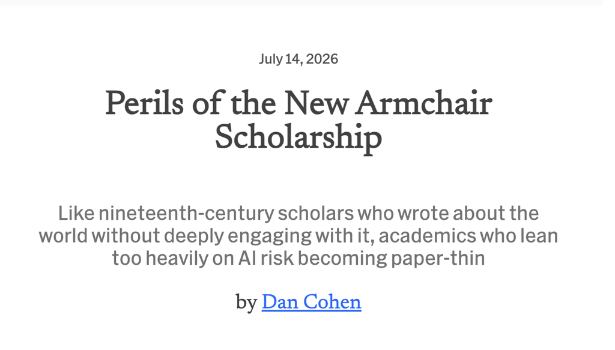

For a lengthier discussion, see https://newsletter.dancohen.org/archive/perils-of-the-new-armchair-scholarship/

## AI biases

- Learns from existing material at the web
  - Most of which is western centered
  - Most of theories and empirical approaches stem from majoritarian voices and overused arguments
  - Reproduces historical inequalities and biases [problem solving research?]
- ‘People pleasing’
- Hallucinations

## Against armchAIr research: Shoe leather approaches

**Shoe-leather**: Doing research with care, effort and attention to details through on-the-ground empirical research, including:

- Quantitative data analysis of originally collected data
- Qualitative fieldwork with field interviews, direct observation, and door-to-door inquiry

**vs.**

**Solely on remote statistical modeling or secondary data**

[figure not shown]

## An example: Lake et al.

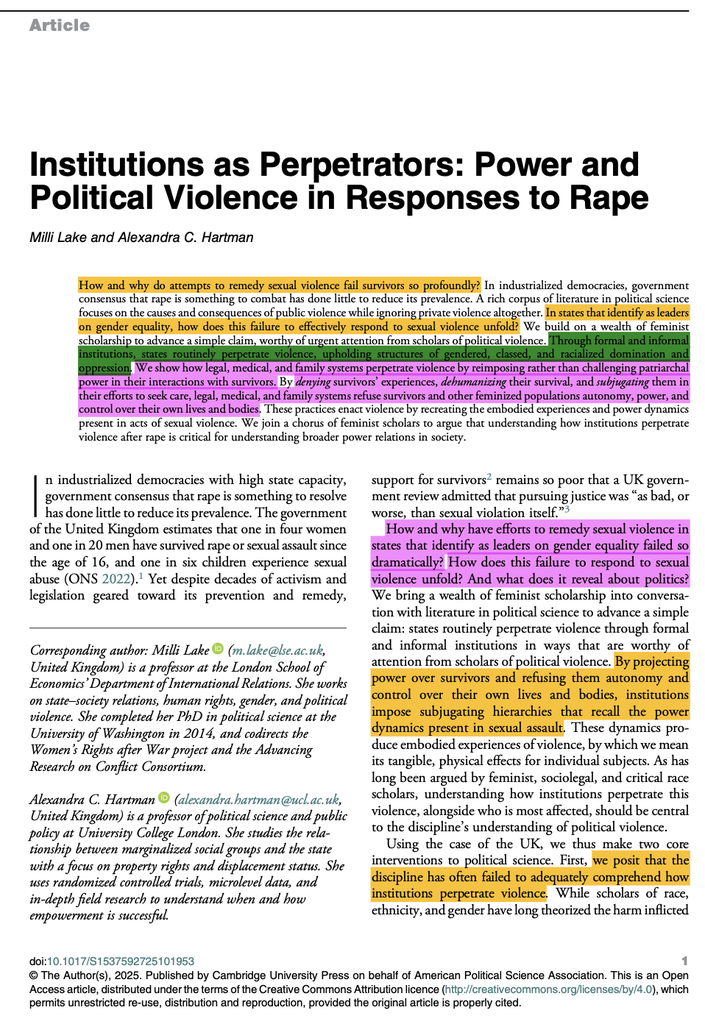

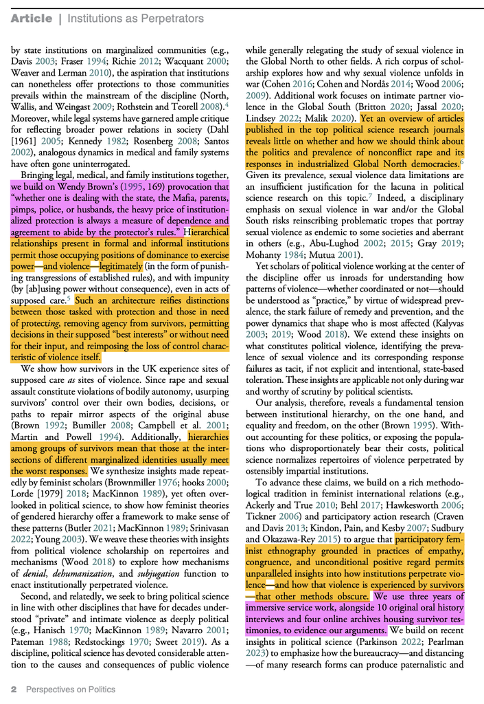

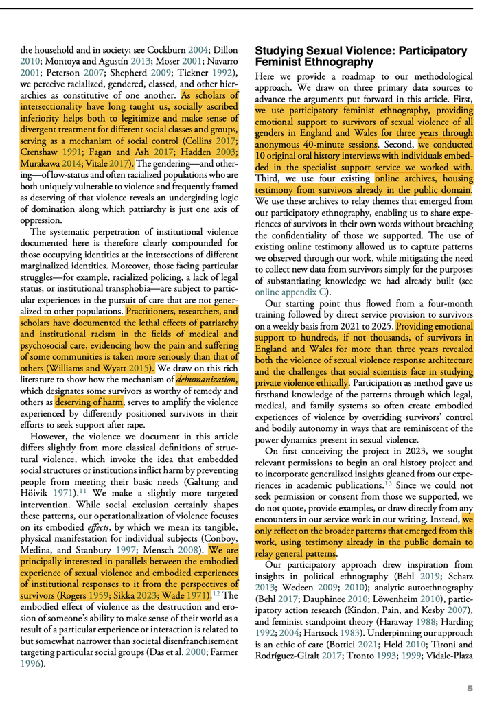

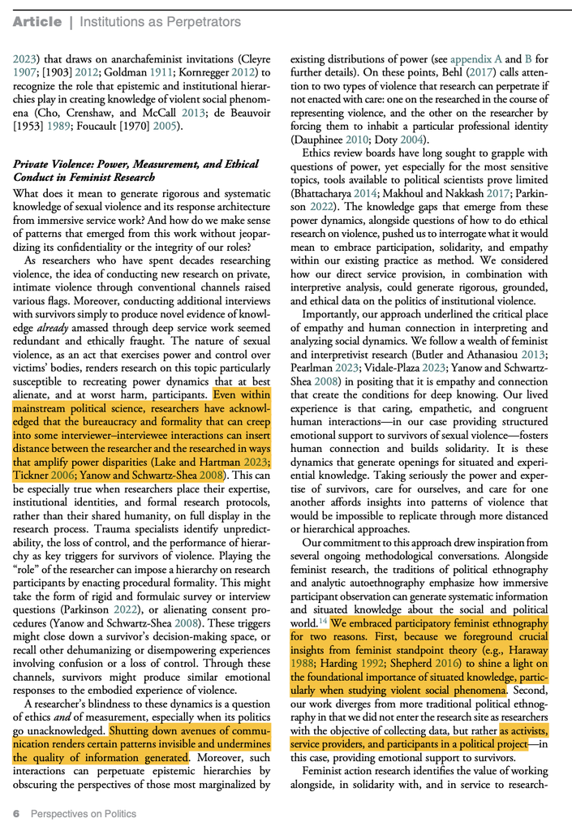

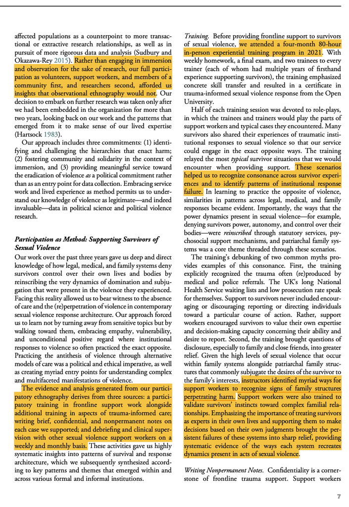

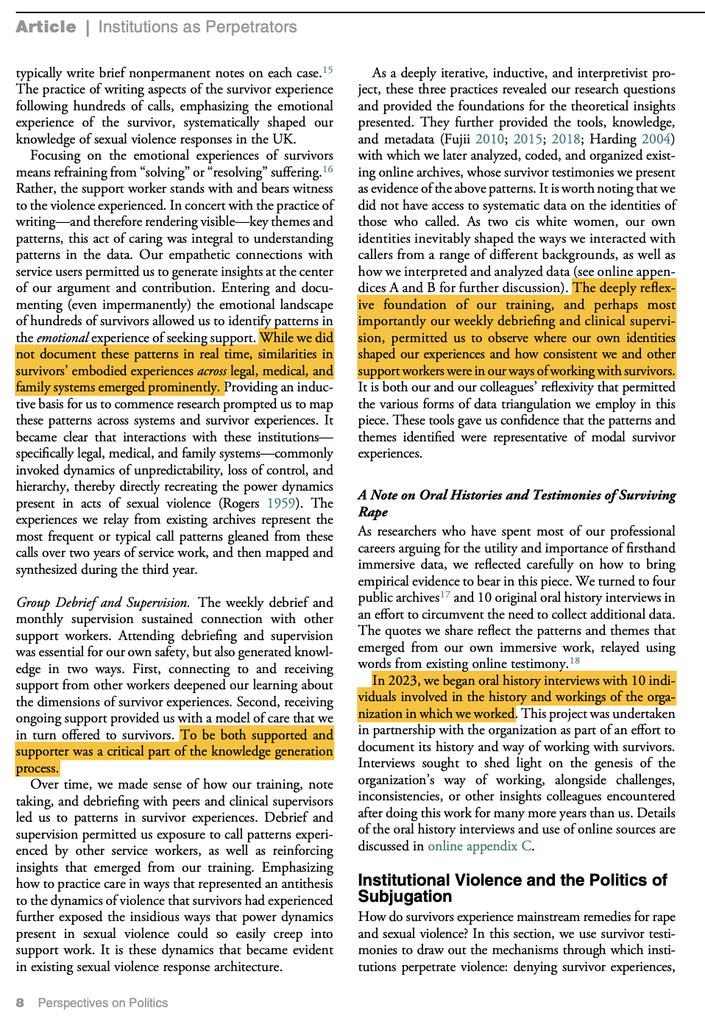

## Another example: Heinze

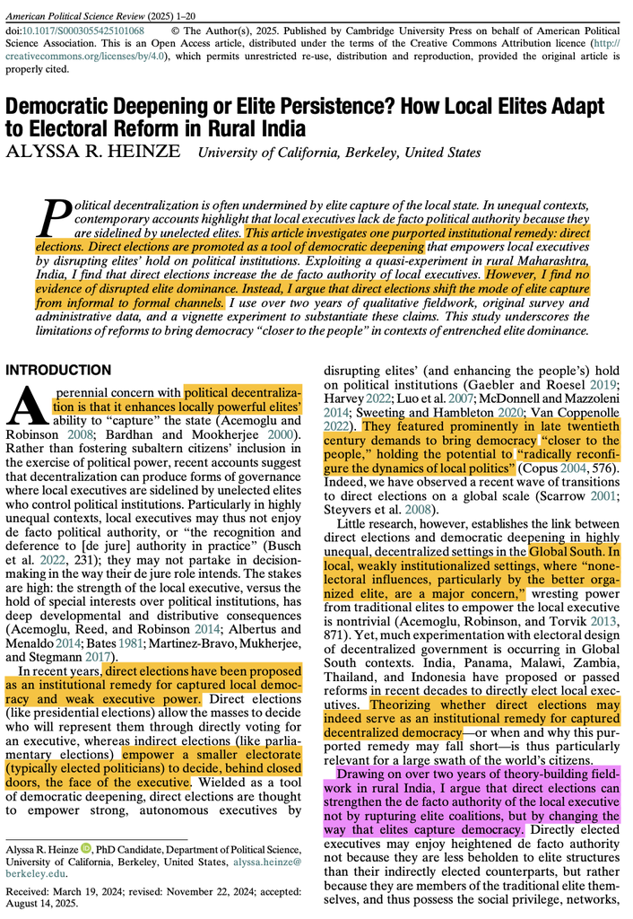

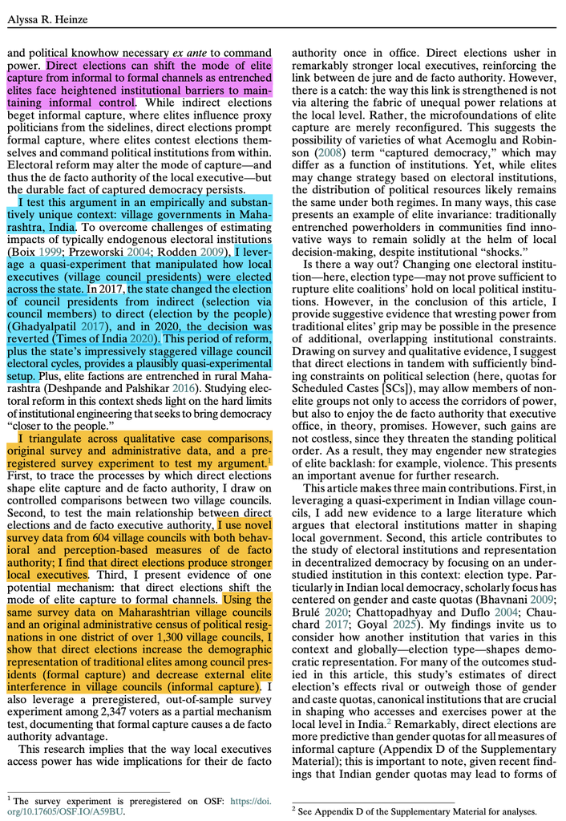

## Let’s recap

What’s the question in each of these two papers? and the answer?

**Heinze**:

**Lake and Hartman**:

- Question: How and why do state remedies for victims of sexual violence fail survivors needs and expectations?
- Answer: States are gendered, classed, racialized, and oppressive institutions. Lelgal, medical, and family systems reimpose patriarchal power in their interaction with survivors.

**Remember** that we are interested in empirical (V), causal questions (X → Y), and mechanisms (how and why X shapes Y).

We need both types of evidence.

- Qualitative will inform about the case, the sequence, and how X affects Y (mechanisms)
- Quantitative will assess to what extent X and Y are associated

**Experiments**

## How do we assess causality?

Randomized controlled trials (RCTs): Type of statistical experiment that minimizes bias through the random allocation of participants to one or more comparison groups.

- At least one group receives the intervention or process under study (a drug, surgical procedure, medical device or diet)
- The other groups receive an alternative treatment, a placebo, or standard care

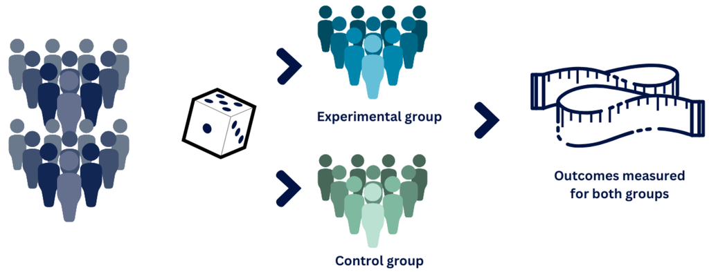

## The logic of RCTs

If assignment to treatment is random

- T and C groups are expected to be similar in all respects except for the treatment (exchangeability)
- Any difference in outcomes between the two groups can be attributed to the treatment (causal effect)

Not observing both potential outcomes (Y(T), Y(C)):

- We can’t estimate the causal effect for any individual (ITE)
- We estimate the average treatment effect (ATE) as the difference in mean outcomes between the two groups with a t-test

[figure not shown]

[figure not shown]

[figure not shown]

## Polio: The Salk vaccine trial

[video not shown]

[Salk was not adored by everyone in science](https://www.youtube.com/watch?v=cym21dpmxL4)

## Can we do RCTs in political science?

Do you remember reading any?

[figure not shown]

## Metaketa

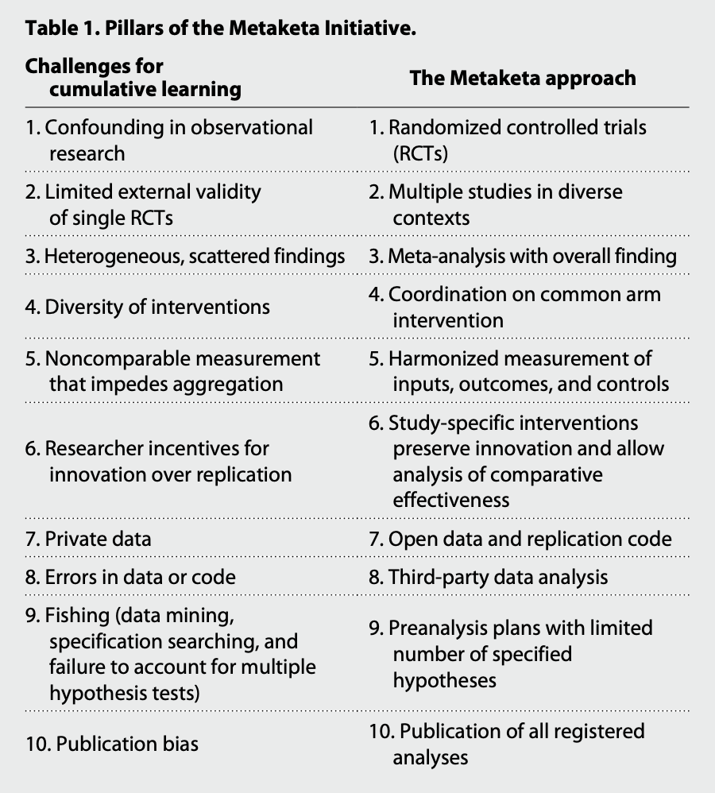

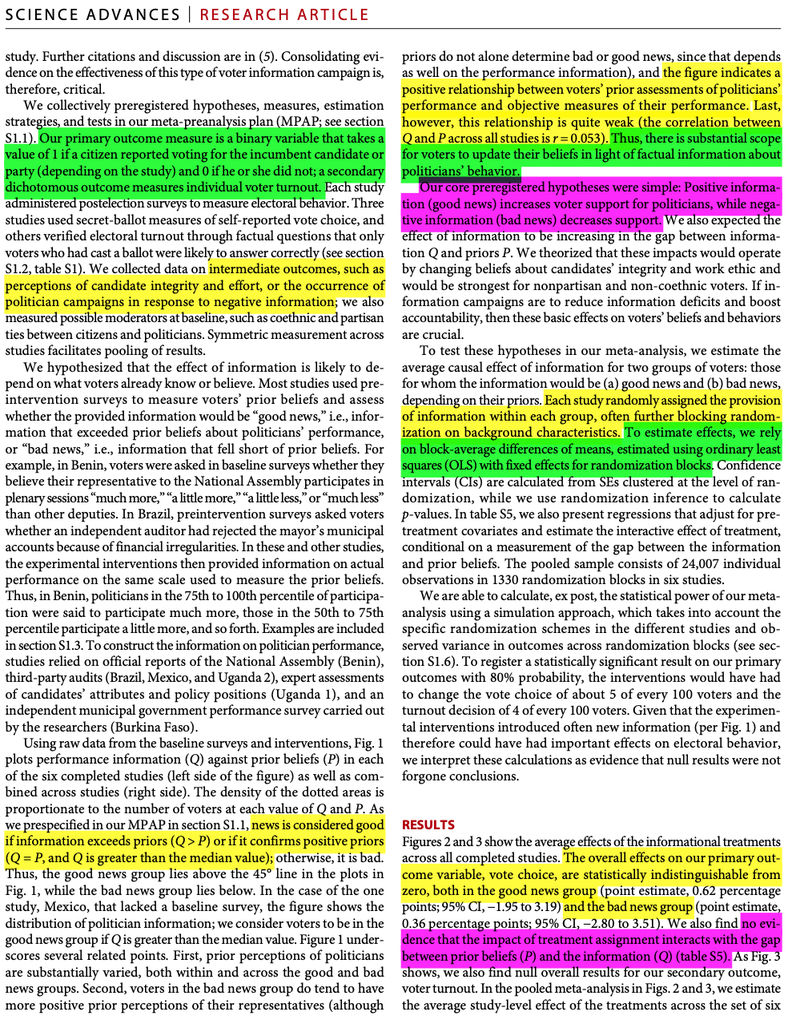

## Metaketa: Null

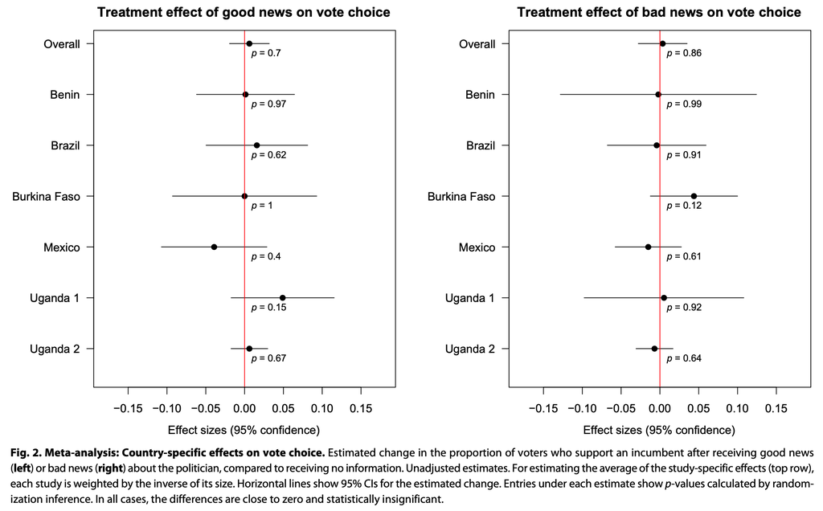

## Metaketa: shoeleather?

And then? Do we learn anything from this null result? Why null?

What explains the weak overall effect on voter behavior of these common, potentially scalable informational interventions?

- There are many necessary steps in a causal chain linking information to voters’ decision-making process and, ultimately, to greater political accountability. In our studies, information existed and was disseminated.
- The extent to which voters understood the information varied markedly across studies, with nonresults in some studies suggesting real difficulties of disseminating information effectively
- Perhaps most critically, however, the information did not, on average, have any discernible effect on perceptions of politicians’ integrity and effort

## Null results

- Can be as informative as significant results
- Null results are often the result of a complex causal chain, where the treatment is not enough to produce the expected effect
- Null results open the door to further research, to understand the mechanisms and conditions under which a treatment works or not

**Problem**: Null results are often more difficult to publish(publication bias)

Evidence from a meta-experiment: Stegmann et al. (2022) [The null results penalty](https://cepr.org/voxeu/columns/null-result-penalty)

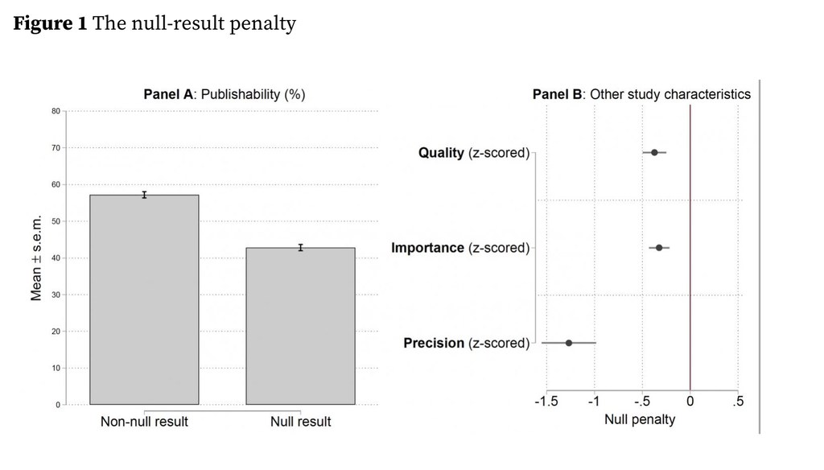

## Meta-experiment?

[figure not shown]

## Experiments: From medical to social sciences

**Medical**

- Randomization of different doses and components
- All human beings are very much equal in their biology, so we can expect similar effects across different populations

**Social**

- Doses and components rarely have linear effects
- Social phenomena are context-dependent, so we can expect different effects across different societies aka. scope conditions

## Experiments in social sciences

## In political science…

- We need to build on theory (observable implications)
- Adapt the design to the social context
- Evaluate the mechanisms that may affect the outcome of interest
- Discuss the scope conditions of the findings

[figure not shown]

## Example: Bursztyn et al. (2020)

Pittsburgh, PA, USA, 2016: Donald Trump won the election with 44.2% of the vote

In 2018, survey to 1,600 registered voters, randomizing whether they received one of these two messages:

- In the 2016 US Presidential Election, Donald Trump won Pittsburgh’s metropolitan area.
- In the 2016 US Presidential Election, Hillary Clinton won Pittsburgh’s county.

Outcome: Donating money to a anti-immigration organization, but then there were two modes (randomized):

- **Public donation**: the donor’s name and donation amount were published on a website
- **Private donation**: the donor’s name and donation amount were not published on a website

## Example: Bursztyn et al. (2020) Results

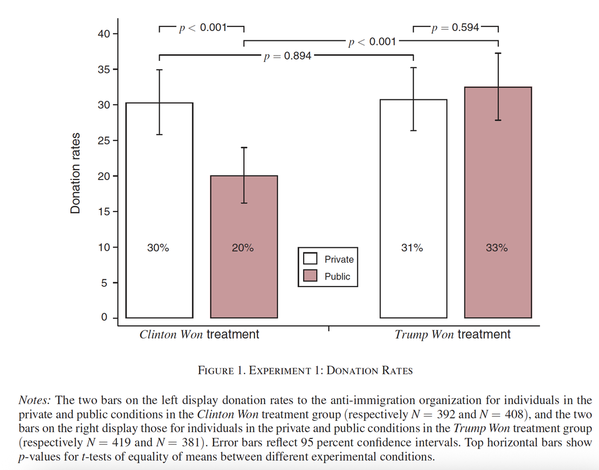

## Like in medical sciences…

- We can´t randomize wars, institutions, social cohesion, identities, etc and we need to get to answers, most of the times, following a shoe-leather approach, with careful and detailed fieldwork

[video not shown]

## Example: Treisman

If traditional elites were so strong (economic, political, and military power), why did countries democratize?

- *It takes “the talents of specific individuals (virtù)” to defeat the vagaries of fortuna* (O’Donnell and Schmitter 1986)
- *Football Autocracy is a game of mistakes, whoever makes the fewest wins survives* (Treisman 2020, from Cruyff)

Have you read Treisman’s paper? What’s the research method?

- Deductive and theory building
- Conceptual definition of *mistake* (non optimal choice, be them due to misinformation or miscalculation): *Democratization by mistake occurs if the regime becomes democratic because of one or more mistakes by the authoritarian incumbents* (p. 5)
- 3 paths to democracy: deliberate democratization, unavoidable democratization, and democratization by mistake.

Democracy by mistake are those cases where autocrats’ mistakes occur less than 3y before the democratization.

## Treisman: What´s a mistake

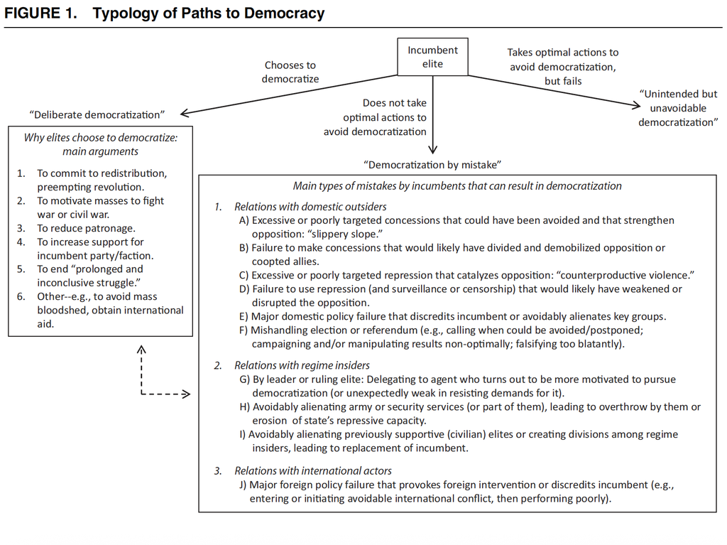

## Treisman: A lesson for

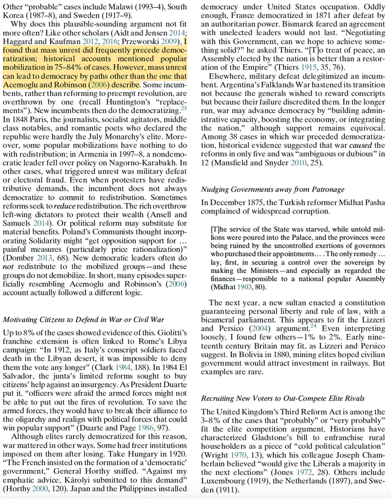

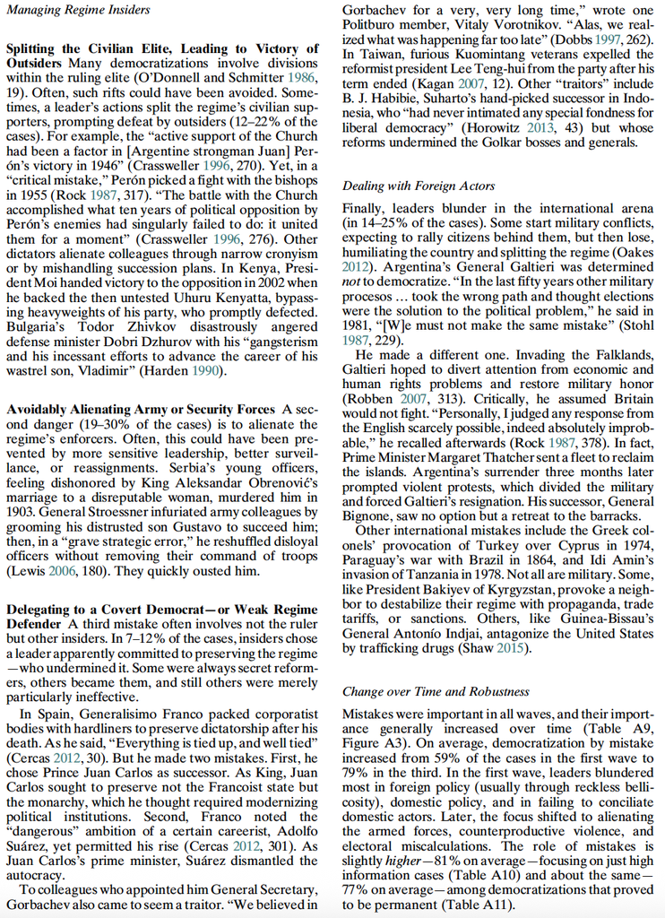

## Treisman: Its main mistake

Is this a paper about the effects of causes or the causes of effects?

- All cases under study are democratizations, so the paper is about the causes of effects
- There’s no variation in the dependent variable, which means we can’t estimate the effect of X (mistakes) on Y (democratization). Why?

**We can’t know if mistakes are equally present in non-democratizing countries**

**If non-democratizing countries also make mistakes, would you say they are a cause of democratization?**

That is selecting on the dependent variable :::

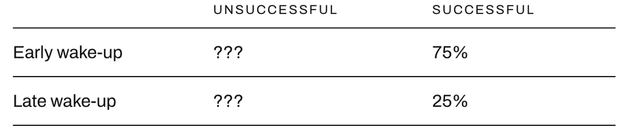

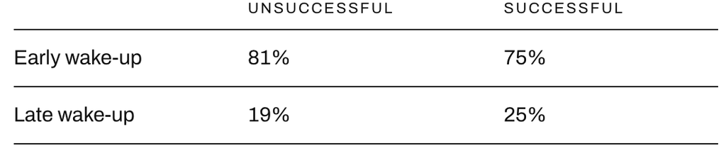

## Treisman: To remember

It is almost impossible to discuss history in causal terms without entertaining counterfactuals (Bunzl 2004; Tetlock and Belkin 1996).

The question is rather how to distinguish “appropriate” or “grounded” counterfactuals from less pertinent ones. Some have suggested a few principles.

## Coming up

**Monday, Sept 28 — Seminar 3**:

- Read Lit and Theory sections: Goyal, T. (2023). Representation from below: How women’s grassroots party activism promotes equal political participation. American Political Science Review, 1–16.
- Read Intro, Concepts, Lit, Theory: Juon, A. (2025). The long-term consequences of power-sharing for ethnic salience. Journal of Peace Research, 62(3), 613–628.

**Friday, Oct 2 — Lecture 4**: Causality, case-studies, and measurement. Visualization with R (ggplot).

- Fearon, J. D. (1991). Counterfactuals and hypothesis testing in political science. World Politics, 43(2), 169–195.
- Pager, D., & Quillian, L. (2005). Walking the talk? What employers say versus what they do. American Sociological Review, 70(3), 355–380.

## Questions?

```css
.center h2 {
  text-align: center;
}
```

I’m also here: smsoler@clio.uc3m.es

[figure not shown]

Research Seminar